# Отчет по Заданию 1

Задание1 выполняло 3 человека:

1. Купина Марина – Head of unit
2. Носков Глеб - analyst
3. Чикунов Максим analyst

# Инструкция по запуску:

Подключенные библиотеки: library(tseries) library(forecast) library(MLmetrics)

Для запуска необходимо открыть файл task1.rmd через RStudio и запустить выполнение программы.

# Цели и подходы к решению задания1:

1. Проверить является ли ряд стационарным в широком смысле.

Для выполнения этого задания воспользуемся тестом Дики-Фуллера, который подтверждает или отвергает гипотезу о стационарности временного ряда. Считаем данные из файла training.csv и проведем тест Дики-Фуллера.

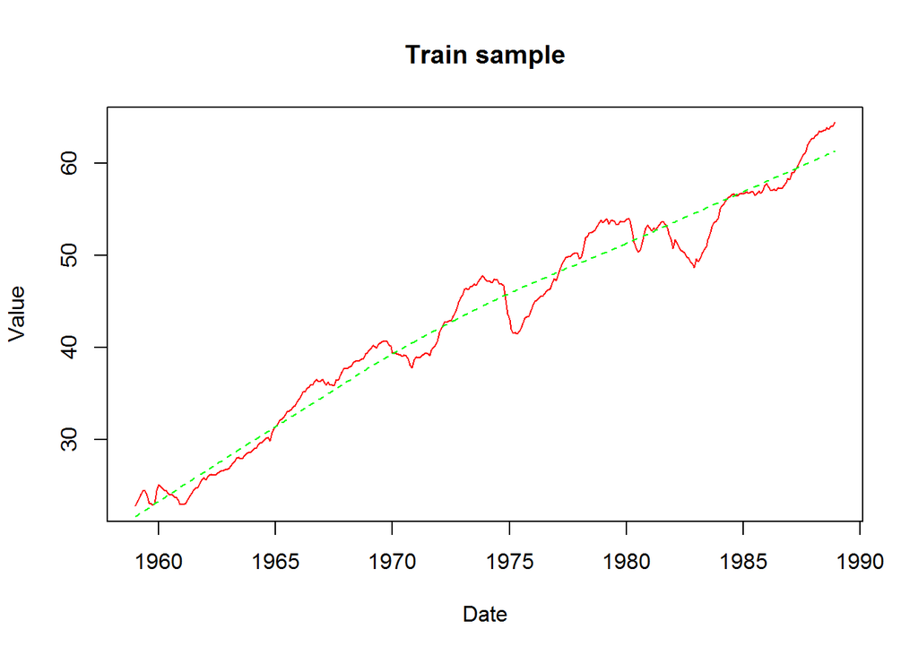

Тест Дики-Фуллера:

```
##
##  Augmented Dickey-Fuller Test
##
## data:  train$Value
## Dickey-Fuller = -3.2505, Lag order = 7, p-value = 0.07962
## alternative hypothesis: stationary
```

Значения p-value выше уровня значимости (5%), что дает нам возможность утверждать,что нулевая гипотеза подтверждается: ряд не стационарен.

2. Разложить временной ряд на тренд, сезональность, остаток в соответствии с аддитивной, мультипликативной моделями. Визуализировать их, оценить стационарность получившихся рядов, сделать выводы.

   Для разложения исходного ряда будем использовать функцию decompose(). О не стационарности исходного ряда может говорить наличие тренда, что подтверждает полученные нами результаты теста Дики Фуллера. Проверим стационарность тренда, сезональности и остатка.

Мультипликативная модель:

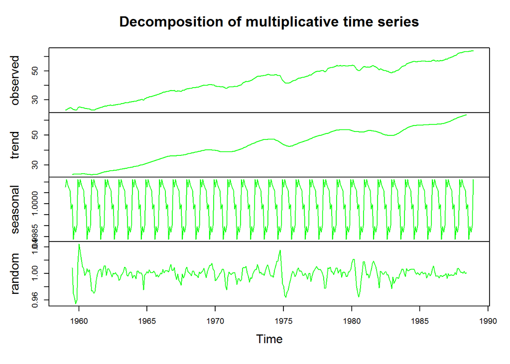

```
##
##  Augmented Dickey-Fuller Test
##
## data:  dc$seasonal[!is.na(dc$seasonal)]
## Dickey-Fuller = -37.814, Lag order = 7, p-value = 0.01
## alternative hypothesis: stationary
```

```
##
##  Augmented Dickey-Fuller Test
##
## data:  dc$trend[!is.na(dc$trend)]
## Dickey-Fuller = -2.853, Lag order = 7, p-value = 0.2169
## alternative hypothesis: stationary
```

```
##
##  Augmented Dickey-Fuller Test
##
## data:  dc$random[!is.na(dc$random)]
## Dickey-Fuller = -7.2542, Lag order = 7, p-value = 0.01
## alternative hypothesis: stationary
```

Из полученных значений p-value мы можем утрвержать, что сезональность – стационарна, тренда - не стационарный, остаток – стационарен.

Аддитивная модель:

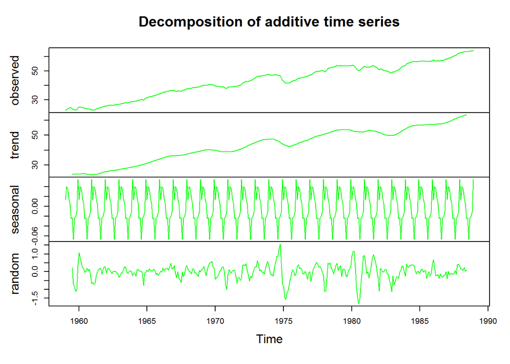

```
##
##  Augmented Dickey-Fuller Test
##
## data:  adddc$seasonal[!is.na(adddc$seasonal)]
## Dickey-Fuller = -63.636, Lag order = 7, p-value = 0.01
## alternative hypothesis: stationary
```

```
##
##  Augmented Dickey-Fuller Test
##
## data:  adddc$trend[!is.na(adddc$trend)]
## Dickey-Fuller = -2.853, Lag order = 7, p-value = 0.2169
## alternative hypothesis: stationary
```

```
##
##  Augmented Dickey-Fuller Test
##
## data:  adddc$random[!is.na(adddc$random)]
## Dickey-Fuller = -6.835, Lag order = 7, p-value = 0.01
## alternative hypothesis: stationary
```

Для аддитивной модели стационарности сезональности, тренда, отстаткован - алогичны.

Интегрируемость будет проверять по определению: Интегрированный временной ряд - нестационарный временной ряд, разности некоторого порядка от которого являются стационарным временным рядом.

```
##
##  Augmented Dickey-Fuller Test
##
## data:  Valuesdiff1
## Dickey-Fuller = -5.0661, Lag order = 7, p-value = 0.01
## alternative hypothesis: stationary
```

Получаем, что разность временного ряда - стационарна => исходный ряд интегрируем. Значит коэффицент интегрируемости d=1

Для моделирования будем использовать модель ARIMA, построенную для ряда первых разностей. Чтобы построить модель нам нужно знать ее порядок, состоящий из 3-х параметров: (p,d,q). Для определения p,q нам необзодимо изучить авторкорреляционную(ACF) и частично автокорреляционную(PACF) функции для ряда первых разностей.

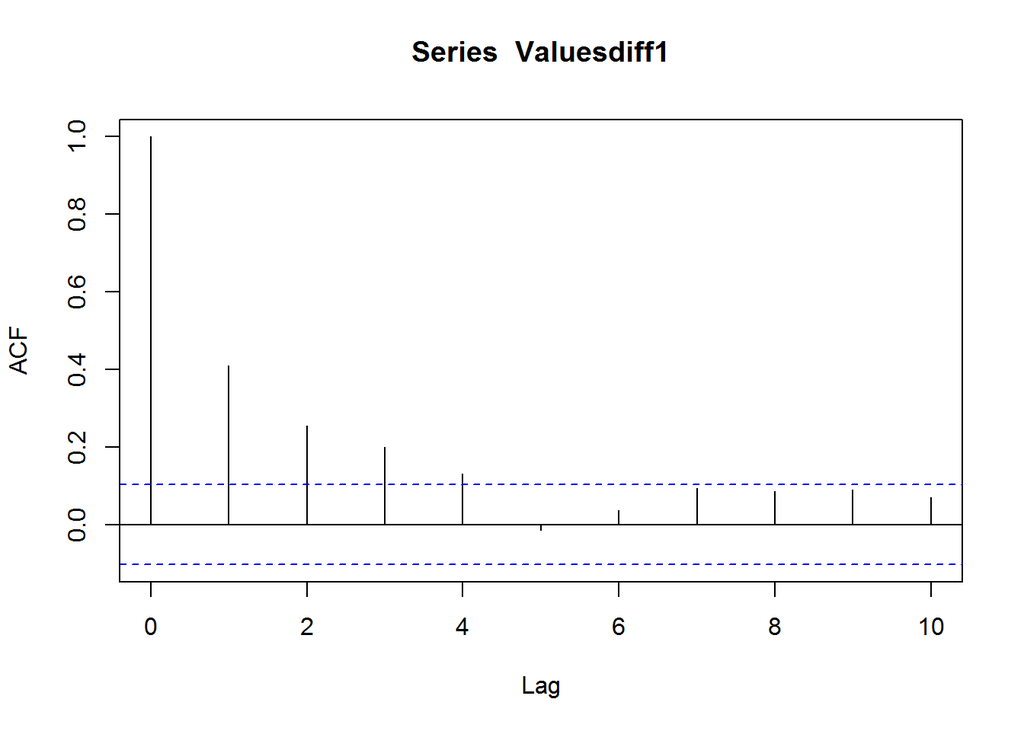

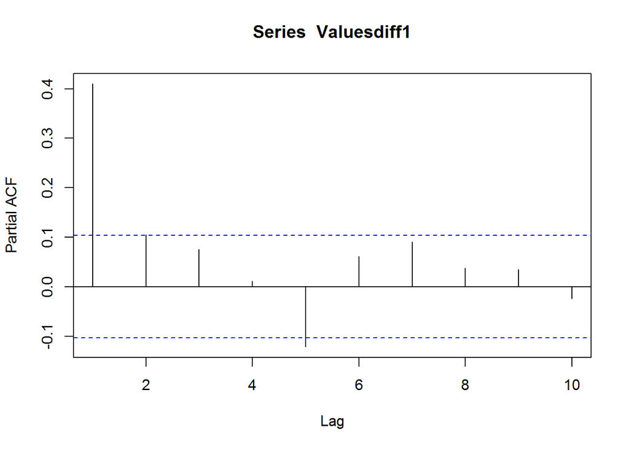

В коррелограмме функции автокорреляции смотрим минимальный лаг, который находится в границах значимости = 5 Определяем количество автокорреляционных коэффициентов сильно отличных от 0 => можем взять коэф. q=4

В коррелограмме функции частичной автокорреляции смотрим минимальный лаг, который находится в границах значимости. Из графика не понятно в ходит ли лаг=2 в границы значимости, поэтому выведем значения функции.

```
##
## Partial autocorrelations of series 'Valuesdiff1', by lag
##
##      1      2      3      4      5      6      7      8      9     10
##  0.410  0.105  0.076  0.011 -0.121  0.062  0.091  0.038  0.035 -0.024
```

Лаг=2 не лежит в границах, поэтому Определяем максимальный номер коэффициента сильно отличный от 0 => можем взять коэф. p=2.

Используем функцию auto.arima(), которая определяет коэффициенты для модели с наименьшим модифицированным критерием Акаике(AICc). Построим несколько моделей с разными коэффициентами и отберем наилучшую модель по информационному критерию Акаике.

```
## Series: train$Value
## ARIMA(2,1,0) with drift
##
## Coefficients:
##          ar1     ar2   drift
##       0.3666  0.1050  0.1172
## s.e.  0.0524  0.0524  0.0337
##
## sigma^2 estimated as 0.1158:  log likelihood=-121
## AIC=249.99   AICc=250.1   BIC=265.52
```

```
##        df      AIC
## arima1  3 258.5099
## arima2  5 253.3399
## arima3  3 255.6413
## arima4  7 257.3009
```

Наименьшему критерию соответствуем модель ARIMA(0,1,4)

Построим графики временного ряда training и test и добавим к ним предсказанные значения

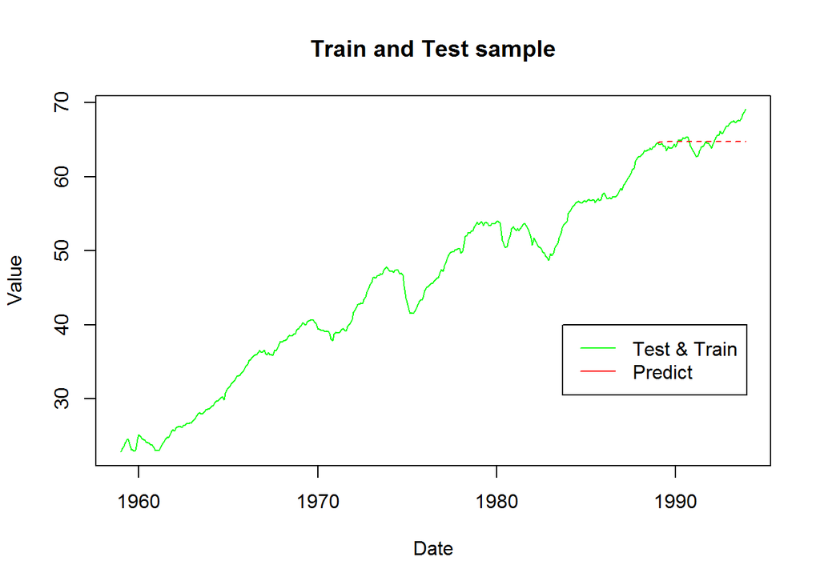

Какие выводы? Из графика видно, что модель ARIMA предсказала среднее значение.?